# Processing Monthly FVCOM Timeseries

Documenting GMRI’s FVCOM Inventory on Box

Published

April 15, 2024

## GMRI-Box FVCOM Monthly Inventory

As part of a previous project, the FVCOM GOM3 hindcast data was downloaded for local (cloud) storage. Data was re-saved as monthly means.

This quarto doc will serve as documentation of how that data was processed into timeseries for regions of interest.

A previous team member (Matt Dzaugis) was responsible for accessing and storing the data, and we are grateful for his time/effort in doing so.

```r
library(raster)
library(sf)
library(fvcom)
library(ncdf4)
library(tidyverse)
library(gmRi)

conflicted::conflict_prefer("select", "dplyr")

proj_path <- cs_path("mills", "Projects/Lobster ECOL")
fvcom_out <- str_c(proj_path, "FVCOM_support/")
```

## Changes in Mesh Over Time

FVCOM/NECOFS mesh structure has been iterated upon over time, with different mesh resolution and the number of variables estimated by the model increasing with newer model iterations moving from gom3 -> NECOFS.

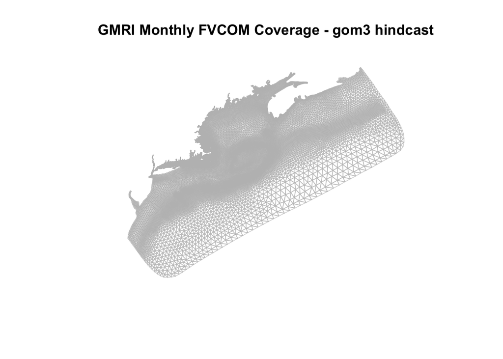

```r
# We can Access Netcdf Files Directly
box_fvcom <- cs_path("res", "FVCOM/FVCOM_gom3_mon_means")
yr <- "2010"
mon <- "01"

# Build the full path
nc_name <- str_c(box_fvcom, yr, mon, ".nc")

# Open (lazy-load) the netcdf connection
x_early <- nc_open(nc_name)

# Can also get the mesh itself as a simple feature collection
gom3_mesh <- get_mesh_geometry(x_early, what = 'lonlat')

# And we can use the mesh to request variables with it
plot(sf::st_geometry(gom3_mesh),
     border = scales::alpha("gray", 0.6),
     main = "GMRI Monthly FVCOM Coverage - gom3 hindcast")
```

```r
# nc_close(x_early)
```

```r
# If we change to later dates what do we get?
yr <- "2017"
mon <- "01"

# Build the full path
nc_name <- str_c(box_fvcom, yr, mon, ".nc")

# Open (lazy-load) the netcdf connection
x_late <- nc_open(nc_name)

# # Can also get the mesh itself as a simple feature collection
# necofs_mesh <- get_mesh_geometry(x_late, what = 'lonlat')
#
# # And we can use the mesh to request variables with it
# plot(sf::st_geometry(necofs_mesh),
#      border = scales::alpha("gray", 0.6),
#      main = "GMRI Monthly FVCOM, NECOFS Mesh")

# nc_close(x_late)
```

# Building Regional Monthly Timseries:

The code below will process the in-house inventory of FVCOM monthly mean data into timeseries for regions of interest relevant to the LOBSTER-ECOL project.

### Trim Mesh to Areas

```r
# Read things in
vts_poly            <- read_sf(str_c(proj_path, "Ecological Data/Spatial_Boundaries/VTSsurvey_nearshore_area.geojson"))
res_shapes         <- cs_path("res", "Shapefiles")
epu_path           <- str_c(res_shapes, "EPU/")
gom_poly           <- read_sf(str_c(epu_path, "individual_epus/GOM.geojson"))
gb_poly            <- read_sf(str_c(epu_path, "individual_epus/GB.geojson"))



# Prep CRS for polygons
gom_poly <- st_transform(gom_poly, st_crs(gom3_mesh))
gb_poly    <- st_transform(gb_poly, st_crs(gom3_mesh))
vts_poly   <- st_transform(vts_poly, st_crs(gom3_mesh))




# Flag the locations that are within the domains
mesh_trim <- function(mesh, domain){

  # Will remove these columns after st_join
  names_drop <- names(domain)[which(names(domain)!="geometry")]
  new_mesh <- mesh %>%
    st_join(domain, join = st_within) %>%
    drop_na() %>%
    dplyr::select(-all_of(names_drop))
  return(new_mesh)
}



# trim them:---------



# Flag the locations that are within the domain
vts_mesh <- mesh_trim(mesh = gom3_mesh, domain = vts_poly)
gom_mesh <- mesh_trim(mesh = gom3_mesh, domain = gom_poly)
gb_mesh  <- mesh_trim(mesh = gom3_mesh, domain = gb_poly)
```

### Validate the Process for 1 Month

```r
# variables
node_var_list <- c('temp', 'salinity')

# Can we pass multiple time indices to get vars
# ncvar_get(x, "time") # Isn't in time units
time_dim <- fvcom_time(x_early)


# Then Can we Grab what we want?
surface_vars <- get_mesh(
  x_early, # Dataset lazyloaded with ncdf4 from THREDDS
  y = 1, # integer, or indices for siglay or siglev (depth indices)
  vars = c(node_var_list),  # Variables we want
  mesh = vts_mesh, # Mesh to get them for
  time = c(1:length(time_dim)), # All time intervals
  )
```

# Get Monthly Summaries for Regions of Interest

```r
# Make a function to do all the steps:

library(furrr)

#' @title Summarize Monthly FVCOM for Mesh Subset
#'
#'
#' @description Grabs surface and bottom measurements from fvcom data stored on box,
#' averages them across the full time dimension of each file, and returns the whole thing
#' as one timeseries with date, and surface/bottom measures for each variable
#'
#' @param start_yr starting year for range of dates
#' @param end_yr ending year for range of dates
#' @param mesh fvcom mesh sf object created with {fvcom} to determine nodes
#' @param folder path to folder where fvcom files are stored
#' @param var_names c() of variable names to grab at surface and bottom
#'
#' @return
#' @export
#'
#' @examples
local_fvcom_to_timeseries <- function(
    start_yr  = 1978,
    end_yr    = 2018,
    mesh      = vts_mesh,
    folder    = cs_path("res", "FVCOM/FVCOM_gom3_mon_means"),
    var_names = c("temp", "salinity")){

  # Path structures
  box_fvcom <- folder
  yrs <- start_yr:end_yr
  mons <- str_pad(1:12, side = "left", width = 2, pad = "0")
  file_list <- map(yrs, ~str_c(.x, mons)) %>% unlist()
  file_list <- setNames(file_list, file_list)

  #return(file_list)
  # Map through the file paths and get the monthly averages as a dataframe
  monthly_vars <- map_dfr(
    file_list,
    possibly(
      .f = function(date_info, file_time){

      # Build the full path to the netcdf file
      fpath <- str_c(box_fvcom, date_info, ".nc")

      # Open (lazy-load) the netcdf connection
      x <- nc_open(fpath)

      # Time dimension info
      time_dim <- fvcom_time(x)

      # Grab surface variables
      surface_vars <- get_mesh(
          x, # Dataset lazyloaded with ncdf4 from THREDDS
          y = 1, # integer, or indices for siglay or siglev (depth indices)
          vars = var_names,  # Variables we want
          mesh = mesh, # Mesh to get them for
          time = c(1:length(time_dim))) # All time intervals

      # Grab Bottom Variables
      bottom_vars <- get_mesh(
          x,
          y = dim(ncvar_get(x, "siglay"))[2], # Bottom depth layer
          vars = var_names,
          mesh = mesh,
          time = c(1:length(time_dim))) # All time intervals

      # regrid and get means
      surface_vars <- raster::stack(
        sapply(
          var_names,
          function(f) { fvcom::rasterize(surface_vars, field = f) },
          simplify = FALSE)) %>%
        cellStats(mean, na.rm = T) %>%
        t() %>%
        as.data.frame() %>%
        setNames(str_c("surf_", names(.)))

      # and regrid the bottom
      bottom_vars <- raster::stack(
        sapply(
          var_names,
          function(f) { fvcom::rasterize(bottom_vars, field = f) },
          simplify = FALSE)) %>%
        cellStats(mean, na.rm = T) %>%
        t() %>%
        as.data.frame() %>%
        setNames(str_c("bot_", names(.)))

      # Combine
      month_summs <- bind_cols(surface_vars, bottom_vars)

      # Close connection:
      nc_close(x)

      # Return the table
      return(month_summs)
      },
      # Spit out NA's if there's trouble
      otherwise = data.frame(
        "surf_temp" = NA,
        "surf_salinity" = NA,
        "bot_temp" = NA,
        "bot_salinity" = NA)),
    .id = "date")

}
```

### VTS Survey Area

```r
# creating vts_fvcom

# How long does this take
Sys.time()
vts_fvcom <-  local_fvcom_to_timeseries(
    start_yr  = 1978,
    end_yr    = 2016,
    mesh      = vts_mesh,
    folder    = cs_path("res", "FVCOM/FVCOM_gom3_mon_means"),
    var_names = c("temp", "salinity")) %>% mutate(
  yr = str_sub(date, 1, 4),
  mn = str_sub(date, 5, 6),
  dt = as.Date(str_c(yr, mn, "01", sep = "-")))
Sys.time()


vts_fvcom  %>%
  ggplot(aes(dt, surf_temp)) +
  geom_line()

# write_csv(vts_fvcom, here::here("data/fvcom_vts_area.csv"))
```

### Gulf of Maine EPU

```r
# # So I got nothing on the full pull...
# gom_small <- local_fvcom_to_timeseries(
#     start_yr  = 1978,
#     end_yr    = 1979,
#     mesh      = gb_mesh,
#     folder    = cs_path("res", "FVCOM/FVCOM_gom3_mon_means"),
#     var_names = c("temp", "salinity"))  %>%
#   mutate(
#   yr = str_sub(date, 1, 4),
#   mn = str_sub(date, 5, 6),
#   dt = as.Date(str_c(yr, mn, "01", sep = "-")))




# time these too
Sys.time()
gom_fvcom <-  local_fvcom_to_timeseries(
    start_yr  = 1978,
    end_yr    = 2016,
    mesh      = gom_mesh,
    folder    = cs_path("res", "FVCOM/FVCOM_gom3_mon_means"),
    var_names = c("temp", "salinity")) %>%
  mutate(
  yr = str_sub(date, 1, 4),
  mn = str_sub(date, 5, 6),
  dt = as.Date(str_c(yr, mn, "01", sep = "-")))
Sys.time()



gom_fvcom  %>%
  ggplot(aes(dt, surf_temp)) +
  geom_line()

# write_csv(gom_fvcom, here::here("data/fvcom_gom_area.csv"))
```

### Georges bank EPU

```r
# and georges bank


# # So I got nothing on the full pull...
# gb_small <- local_fvcom_to_timeseries(
#     start_yr  = 1978,
#     end_yr    = 1979,
#     mesh      = gb_mesh,
#     folder    = cs_path("res", "FVCOM/FVCOM_gom3_mon_means"),
#     var_names = c("temp", "salinity"))  %>%
#   mutate(
#   yr = str_sub(date, 1, 4),
#   mn = str_sub(date, 5, 6),
#   dt = as.Date(str_c(yr, mn, "01", sep = "-")))


# Run the full thing
Sys.time()
gb_fvcom <-  local_fvcom_to_timeseries(
    start_yr  = 1978,
    end_yr    = 2016,
    mesh      = gb_mesh,
    folder    = cs_path("res", "FVCOM/FVCOM_gom3_mon_means"),
    var_names = c("temp", "salinity")) %>%
  mutate(
  yr = str_sub(date, 1, 4),
  mn = str_sub(date, 5, 6),
  dt = as.Date(str_c(yr, mn, "01", sep = "-")))
Sys.time()


# Plot Check
gb_fvcom  %>%
# gb_small  %>%
  ggplot(aes(dt, surf_temp)) +
  geom_line()

# write_csv(gb_fvcom, here::here("data/fvcom_gb_area.csv"))
```

# Review What we Have Processed:

```r
vts_fvcom <- read_csv(here::here("data/fvcom_vts_area.csv"))
gom_fvcom <- read_csv(here::here("data/fvcom_gom_area.csv"))
gb_fvcom <- read_csv(here::here("data/fvcom_gb_area.csv"))



all_areas <- bind_rows(
  mutate(vts_fvcom, area = "Nearshore - VTS"),
  mutate(gom_fvcom, area = "Offshore - Gulf of Maine"),
  mutate(gb_fvcom, area = "Offshore - Georges Bank")
) %>% pivot_longer(
  cols = c(2:5),
  names_to = "var_name",
  values_to = "val"
)
```

**Monthly**

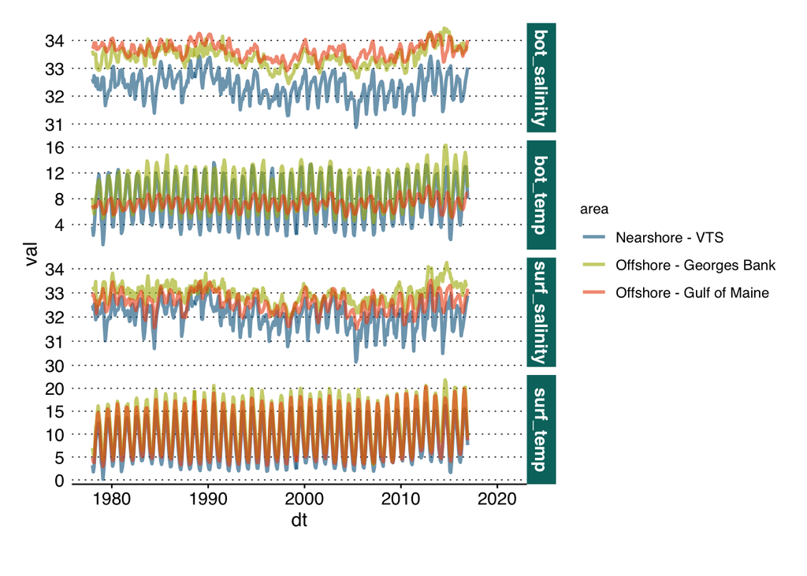

```r
all_areas %>%
ggplot() +
  geom_line(aes(dt, val, color = area), linewidth = 1, alpha = 0.6) +
  facet_grid(var_name~., scales = "free") +
  scale_color_gmri() +
  theme_gmri()
```

**Yearly**

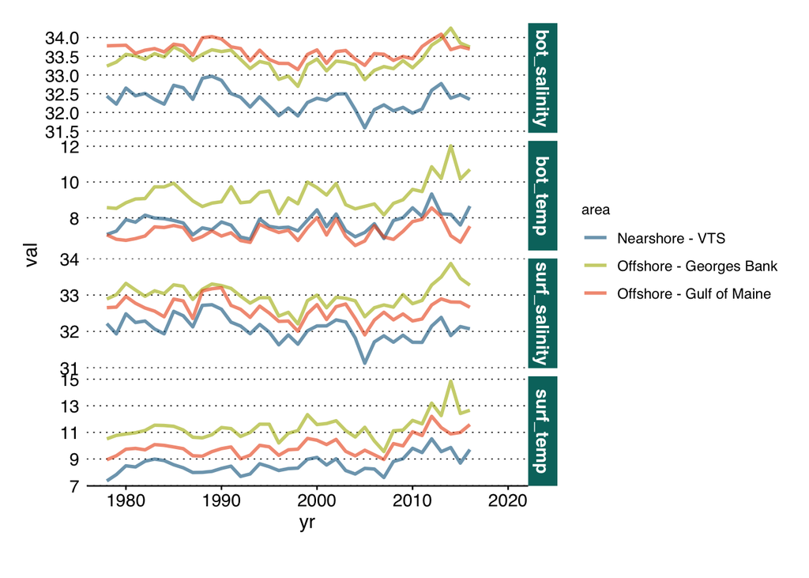

```r
all_areas %>%
  group_by(area, var_name, yr = lubridate::year(dt)) %>%
  summarise(val = mean(val, na.rm = T)) %>%
ggplot() +
  geom_line(aes(yr, val, color = area), linewidth = 1, alpha = 0.6) +
  facet_grid(var_name~., scales = "free") +
  scale_color_gmri() +
  theme_gmri()
```